# Coastal Chum Pilot Genotyping

```r
require(poppr)
require(genepop)
require(graph4lg)
require(related)
require(adegenet)

require(tidyverse)
require(knitr)
require(magrittr)
```

# Readme

This notebook is part of an rstudio project. If you’d like to pre-rendered figures, read a summary of analysis and view code, please open the relevant html file in a browser.

The full project with data (except raw sequencing data) and results is archived as a github repository at [https://github.com/david-dayan/chum_coastal_pilot]

# Summary

GTseq genotyping for the 2021 OR Coastal chum pilot study. [Analysis Notebook is here](https://github.com/david-dayan/chum_coastal_pilot/blob/main/coastal_chum_pilot_study_notebook.html) See the analysis notebook for details

# Data

Run 1: The first run was the test plate for the Oke350 panel. Raw compressed reads are at /dfs/Omalley_Lab/dayan/coastal_chinook_2020/full_panel/demux/keta_reads .

95 samples library from four populations spiked into a larger coastal chinook run. Demuxed with deML. The total number of reads was 50,680,864 .

Run 2:  
Raw sequencing data is at /dfs/Omalley_Lab/dayan/chum_pilot_2021 and /dfs/Omalley_Lab/fitz/Runs/4774 . It was demultiplexed by the sequencing center

Raw data is from the SFGL Illumina 020 run and include some samples from run 1.

285 samples total

Intermediate data/results are in the directory /dfs/Omalley_Lab/dayan/chum_pilot_2021

# Genotyping Pipeline Summary

**Genotype** - Call genotypes: Use GTseq_Genotyper_v3.1.pl to call genotypes on demultiplexed reads.  
- Compile: After all the individual genotypes are called, compile them into a single output using the GTseq_GenoCompile_v3.pl script.

**QAQC Check:**  
- Check positive and negative controls (for plate flipping, other library prep errors)  
- Check technical replicates  
- Remove controls and replicates if all looks good

**Filtering:**  
We use an iterative filtering process, first removing individuals and genotypes with extremely low genotyping success, or high signal of contimination, then moving to a second round with our final filtering cutoffs. Then we conduct other filtering.

IFI and Missingness Round 1: - inds removed with genotying success less than 70%  
- loci removed with > 50% missingness - inds removed with IFI > 10

Other filtering:

- Missingness (loci) > 10% (examine moderately bad loci for incorrect allele correction issues or paralogs and attempt to rescue)
- Skewed or high variance allele count ratios (examine loci for potential paralogs)
- Remove monomorphic SNPs
- Remove duplicated individuals

# Genotyping

**Main Genotyper**  
Note only run for the run 2 samples, run 1 already complete, will add in at compiler.

```bash
##### decompress script

# note 1: this is a script to save and submit as a job, save everything below the long ########### below
#note 2: the number of threads to use (-t option) is hardcoded to match the number of input files, change this number to reflect how many fastq.gz files you have

#################################
#!/bin/bash
#$ -S /bin/bash
#$ -t 1-289
#$ -tc 20
#$ -N decompress
#$ -cwd
#$ -o $JOB_NAME_$TASK_ID.out
#$ -e $JOB_NAME_$TASK_ID.err

FASTQS=(`ls *fastq.gz`)
INFILE=${FASTQS[$SGE_TASK_ID -1]}

gunzip -c $INFILE > ${INFILE%.gz}

#save as script and submit this with qsub -q harold scriptname
####################################
```

```bash
#!/bin/bash
#$ -S /bin/bash
#$ -t 1-289
#$ -tc 30
#$ -N GTseq-genotyperv3
#$ -cwd
#$ -o $JOB_NAME_$TASK_ID.out
#$ -e $JOB_NAME_$TASK_ID.err

export PERL5LIB='/home/fw/dayand/perl5/lib/perl5/x86_64-linux-thread-multi/'

FASTQS=(`ls -1 ./*fastq`)
INFILE=${FASTQS[$SGE_TASK_ID -1]}
OUTFILE=$(basename ${INFILE%.fastq}.genos)

GTSEQ_GENO="/dfs/Omalley_Lab/dayan/software/GTseq-Pipeline/GTseq_Genotyper_v3.1.pl
"

PROBE_SEQS="/dfs/Omalley_Lab/dayan/software/GTseq-Pipeline/Oke_GTseq350_ProbeSeqs.csv"

perl $GTSEQ_GENO $PROBE_SEQS $INFILE > $OUTFILE

#save this code chunk as a file on the server and submit this with qsub -q harold scriptname from the directory you want the output .genos files
```

Here copied the genos files from run 1 into the directory.

```bash
# rename all the run 1 genos file to reflect run
for file in *.genos; do
    mv "$file" "${file%.genos}_run1.genos"
done

# move to main genos directory
```

```bash
SGE_Batch -q harold -r compile -c 'perl /dfs/Omalley_Lab/dayan/software/GTseq-Pipeline/GTseq_GenoCompile_v3.pl > Oke_2021_coastal_genos_0.1.csv'

#also collect marker info
bash
touch marker_info.txt
for file in ./*genos
do
    awk ' FS="," {print FILENAME,$1,$2,$3,$6,$7,$8}' $file >> marker_info.txt
done
```

# Filtering

## Controls and Replicates

### Controls

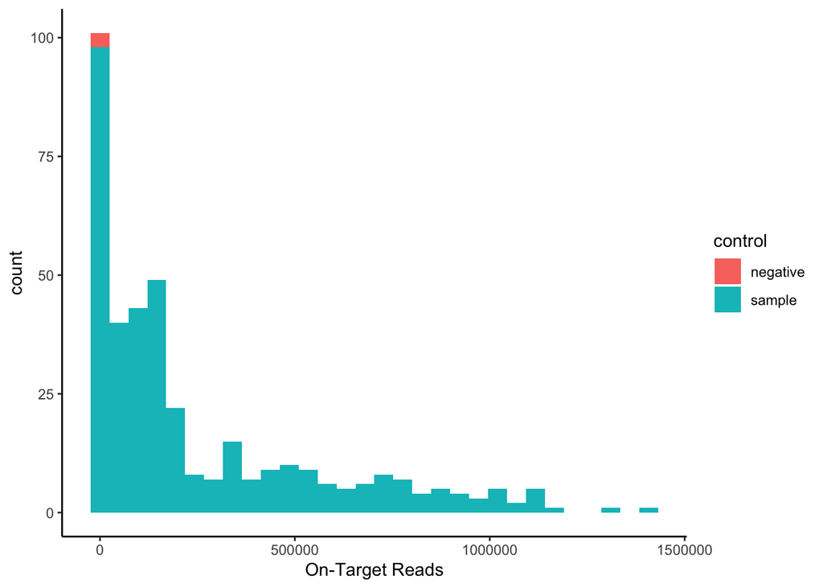

```r
# LOCAL R

# first I cleaned up the sample names in the output compiled genotype file (.csv) with regex in a text editor - separated adapter info from sample name etc, you may not need to do this depending on who did your demultiplexing

# then read this file in to R
genos_0.1 <- read_csv("genotype_data/Oke_2021_coastal_genos_0.1.csv")

# lets set a value to mark controls
# here controls contained "positive," "negative" in their sample names so used simple pattern matching to create a new column

genos_0.1 <- genos_0.1 %>%
  mutate(control = ifelse(grepl("positive", Sample), "positive", ifelse(grepl("negative", Sample), "negative", "sample")))

# great let's plot
ggplot()+geom_histogram(data = genos_0.1, aes(x = `On-Target Reads`, fill= control)) + theme_classic()
```

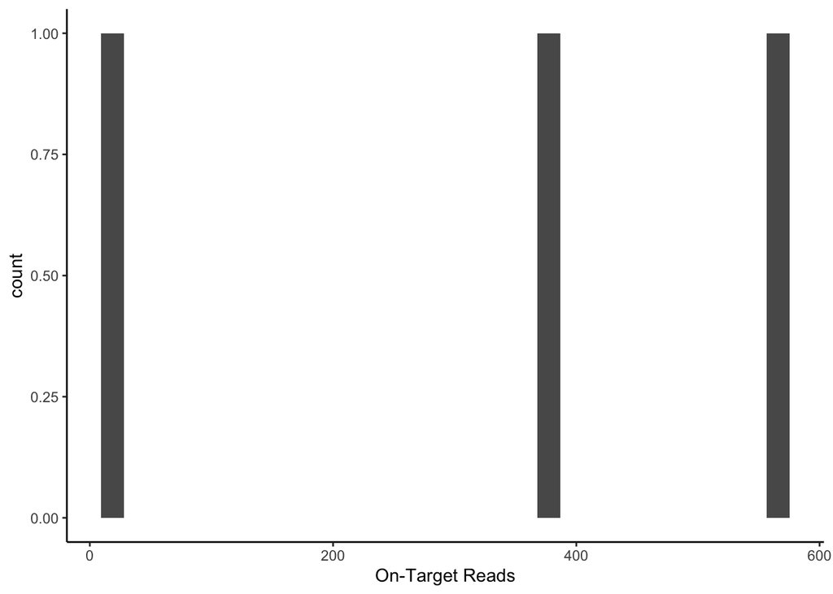

```r
ggplot()+geom_histogram(data = genos_0.1[genos_0.1$control=="negative",], aes(x = `On-Target Reads`)) + theme_classic()
```

Nope, looks good to go.

### Replicates

Some samples were replicated, both within and acorss runs let’s check for concordance in the genotypes, the pick the sample with better GT success and throw out the duplicate.

```r
#LOCAL R
# Some samples were actually run in triplicateor quadrupled which completely broke the script below
# lets get rid of those

# here we filter out our known controls and create our next dataset genos_0.11
genos_0.11 <- genos_0.1 %>%
  filter(control == "sample")

genos_0.11 %<>%
  mutate(sample_simple = str_extract(Sample, "[:upper:][:lower:]{2}[AJCU][RC]\\d{2}\\w{4}_\\d{4}"))

#find the triplicate (or more) samples, and keep the two with greatest on target read dpeth
count(genos_0.11, sample_simple) %>%
  arrange(desc(n))
```

| sample_simple | n |
| --- | --- |
| OkeCC19NEHR_0001 | 4 |
| OkeCC19TILR_0019 | 4 |
| OkeCC19MILC_0028 | 3 |
| OkeCC19MILC_0049 | 3 |
| OkeCC19NEHR_0026 | 3 |
| OkeCC19NEHR_0029 | 3 |
| OkeCC19TILR_0013 | 3 |
| OkeCC19TILR_0016 | 3 |
| OkeCC19TILR_0031 | 3 |
| OkeCC19TILR_0034 | 3 |

[output cut: 256 more lines]

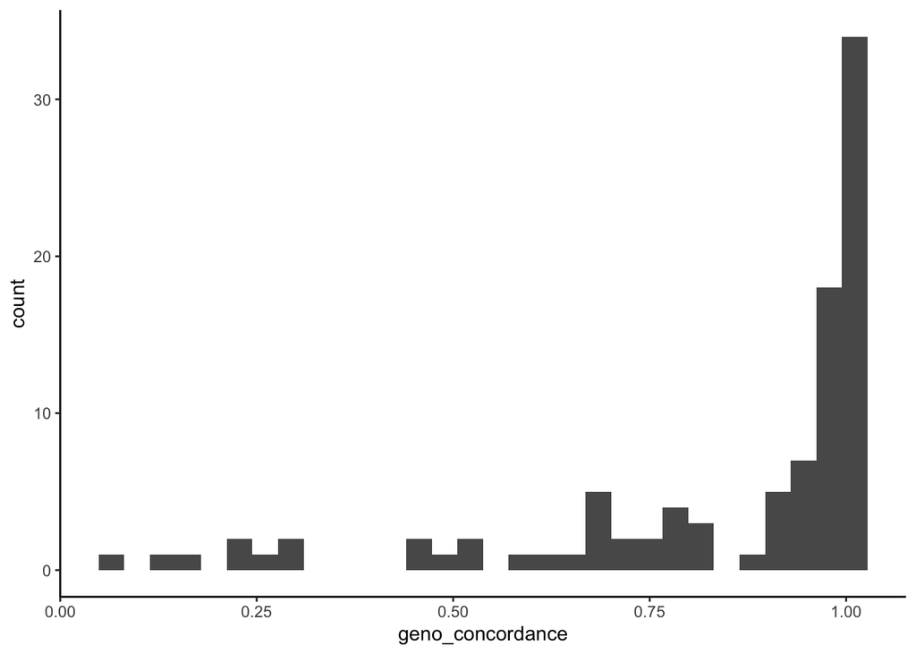

```r
genos_0.11 %<>%
  group_by(sample_simple) %>%
  slice_max(order_by = `On-Target Reads`, n = 2)

#now let's get duplicated samples
dups <- genos_0.11[genos_0.11$sample_simple %in% genos_0.11$sample_simple[duplicated(genos_0.11$sample_simple)],]
dups <- dups[order(dups$sample_simple),]

# next we'll calculate the percent concordance among replicates
# woof I don't see a good way around using a nested for loop here, maybe fix this in the future

dups_genos <- dups[,9:ncol(dups)-2] #caution, possible hardcoding here, grab genotpyes and leave metadata out
rep_info <- matrix(ncol=ncol(dups_genos), nrow=nrow(dups_genos)/2)
colnames(rep_info) <- colnames(dups_genos)
for (j in 1:(nrow(dups_genos)/2)) {
for (i in 1:ncol(dups_genos)) {
  rep_info[j,i] <- sum(dups_genos[(j*2)-1,i]==dups_genos[(j*2),i])
}
  }

geno_concordance <- as.data.frame(as.matrix(rep_info)) %>%
  rowMeans()

rep_data <- as.data.frame(cbind(dups[c(1:length(geno_concordance))*2,1], geno_concordance))
ggplot(data=rep_data)+geom_histogram(aes(x=geno_concordance))+theme_classic()
```

```r
#get the bad samples
bad_reps_samples <- rep_data %>%
  filter( geno_concordance < 0.50) %>%
  mutate(sample_simple = str_extract(Sample, "[:upper:][:lower:]{2}[AJCU][RC]\\d{2}\\w{4}_\\d{4}")) %>%
  pull(sample_simple)

bad_reps <- genos_0.11 %>%
  filter(sample_simple %in% bad_reps_samples)
bad_reps[order(bad_reps$Sample),]
```

| Sample | Raw Reads | On-Target Reads | %On-Target | %GT | IFI | Oke_ACOT_100 | Oke_APOB_60 | Oke_ATP5L_105 | Oke_AhR1_278 | Oke_CATB_60 | Oke_CD123_62 | Oke_CKS1_70 | Oke_CKS_389 | Oke_CO1A1_72 | Oke_CTR2_82 | Oke_DBLOH_79 | Oke_DCXR_87 | Oke_DM20_548 | Oke_EF2_394 | Oke_GNMT_100 | Oke_GPDH_191 | Oke_H2AX_72 | Oke_HP_182 | Oke_IL8r2_406 | Oke_IL8r_272 | Oke_KPNA2_87 | Oke_LAMP2_186 | Oke_METK2_97 | Oke_MLRN_63 | … |
| --- | --- | --- | --- | --- | --- | --- | --- | --- | --- | --- | --- | --- | --- | --- | --- | --- | --- | --- | --- | --- | --- | --- | --- | --- | --- | --- | --- | --- | --- | --- |
| OkeCC19MILC_0061_CAAATT_TATCAC_S47_R1_001 | 668482 | 2722 | 0.41 | 28.86 | 2.73 | 00 | 00 | 00 | TT | 00 | AG | 00 | 00 | 00 | 00 | 00 | 00 | 00 | 00 | 00 | 00 | 00 | 00 | TT | AA | 00 | 00 | 00 | 00 | … |
| OkeCC19MILC_0061_CTGATA_GCTCAA_S285_R1_001 | 1305418 | 488175 | 37.40 | 94.86 | 0.17 | CC | TT | CG | TT | CC | GG | GG | GG | GA | TT | TT | TT | GT | CC | CT | TA | CT | AA | TT | AA | 00 | GG | TT | GA | … |
| OkeCC19NEHR_0007_CAAATT_GTAAGT_S54_R1_001 | 868543 | 8839 | 1.02 | 78.86 | 3.18 | CC | TT | 00 | TT | CC | GG | GG | GG | GA | CT | TT | TT | 00 | CC | 00 | TT | 00 | AA | TT | AA | 00 | GG | TT | GA | … |
| OkeCC19NEHR_0007_run1 | 532710 | 1024 | 0.19 | 1.43 | 0.00 | 00 | 00 | 00 | 00 | 00 | 00 | 00 | 00 | 00 | 00 | 00 | 00 | 00 | 00 | 00 | 00 | 00 | 00 | 00 | 00 | 00 | 00 | 00 | 00 | … |
| OkeCC19NEHR_0009_CAAATT_TCAAAG_S55_R1_001 | 765932 | 472 | 0.06 | 0.29 | 0.00 | 00 | 00 | 00 | 00 | 00 | 00 | 00 | 00 | 00 | 00 | 00 | 00 | 00 | 00 | 00 | 00 | 00 | 00 | 00 | 00 | 00 | 00 | 00 | 00 | … |
| OkeCC19NEHR_0009_CTGATA_GTTGGA_S286_R1_001 | 1825304 | 766766 | 42.01 | 94.86 | 0.19 | CC | CT | CG | TT | CC | AG | GG | GA | AA | CT | CT | TT | GT | CT | TT | TT | CT | AA | TT | AA | 00 | GG | TT | GA | … |
| OkeCC19NETR_0001_CAAATT_ATCAAA_S74_R1_001 | 913034 | 8437 | 0.92 | 86.86 | 1.68 | CC | CT | CG | TT | CC | AG | GG | GA | GA | CT | CT | TT | GT | CC | TT | TT | CT | AC | TT | AA | 00 | GG | TT | GA | … |
| OkeCC19NETR_0001_CTGATA_AGGTGT_S234_R1_001 | 834929 | 1027 | 0.12 | 3.14 | 8.33 | 00 | 00 | 00 | 00 | 00 | GG | 00 | 00 | 00 | 00 | 00 | 00 | 00 | 00 | 00 | 00 | 00 | 00 | 00 | 00 | 00 | 00 | 00 | 00 | … |
| OkeCC19NETR_0003_CAAATT_CTGGTT_S76_R1_001 | 871255 | 7906 | 0.91 | 75.71 | 3.43 | CC | CT | 00 | TT | CC | AG | GG | GG | GA | CT | TT | TT | 00 | CC | CC | 00 | 00 | AA | TT | AA | 00 | GG | TT | 00 | … |
| OkeCC19NETR_0003_CTGATA_CGTGAT_S236_R1_001 | 538113 | 349 | 0.06 | 1.14 | 0.00 | 00 | 00 | 00 | 00 | 00 | 00 | 00 | 00 | 00 | 00 | 00 | 00 | 00 | 00 | 00 | 00 | 00 | 00 | 00 | 00 | 00 | 00 | 00 | 00 | … |

[output cut: 12 more lines]

All replicates with low concordance seem to be due to one or both sample with very low on-target reads. Let’s keep the replicate with greater on-target reads.

```r
# LOCAL R

#this writes a new dataset (0.2) by choosing the samples within duplicates and keeping the one with the highest genotyping success
genos_0.2 <- genos_0.11 %>%
  group_by(sample_simple) %>%
  filter(`On-Target Reads` == max(`On-Target Reads`))
```

After removing replicates and controls, let’s make a note of unfiltered sample/population counts

```r
genos_0.2 %<>%
  mutate(pop = str_sub(Sample, 8, 11)) %>%
  ungroup()

count(genos_0.2, pop)
```

|  | pop | n |
| --- | --- | --- |
| 1 | COOR | 3 |
| 2 | MILC | 74 |
| 3 | NEHR | 50 |
| 4 | NETR | 26 |
| 5 | SILR | 3 |
| 6 | TILR | 100 |
| 7 | YAQR | 10 |

Note that 10 of the archival scale samples (in metadata) weren’t included in the library. So there is a discrepancy between the unfiltered genotype sample size and the metadata sample size.

## IFI and Missingness

First we filter individuals and loci on IFI, and missingness.

Let’s take a look at the distribution of these values before any filtering

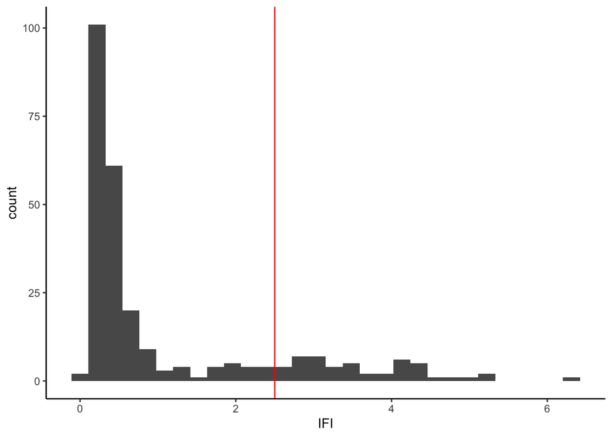

```r
ggplot(genos_0.2)+geom_histogram(aes(x=IFI))+geom_vline(aes(xintercept= 2.5), color="red")+theme_classic()
```

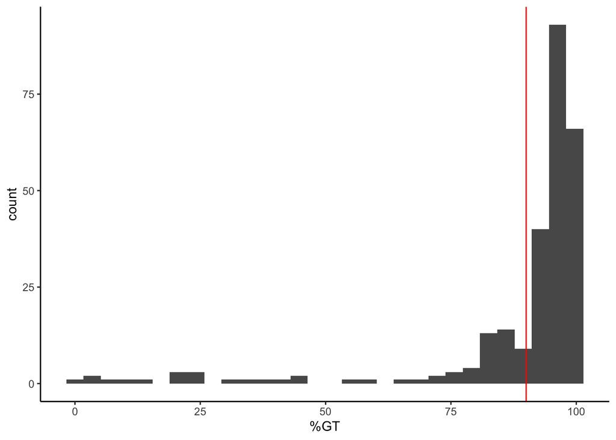

```r
ggplot(genos_0.2)+geom_histogram(aes(x=`%GT`))+geom_vline(aes(xintercept= 90), color="red")+theme_classic()
```

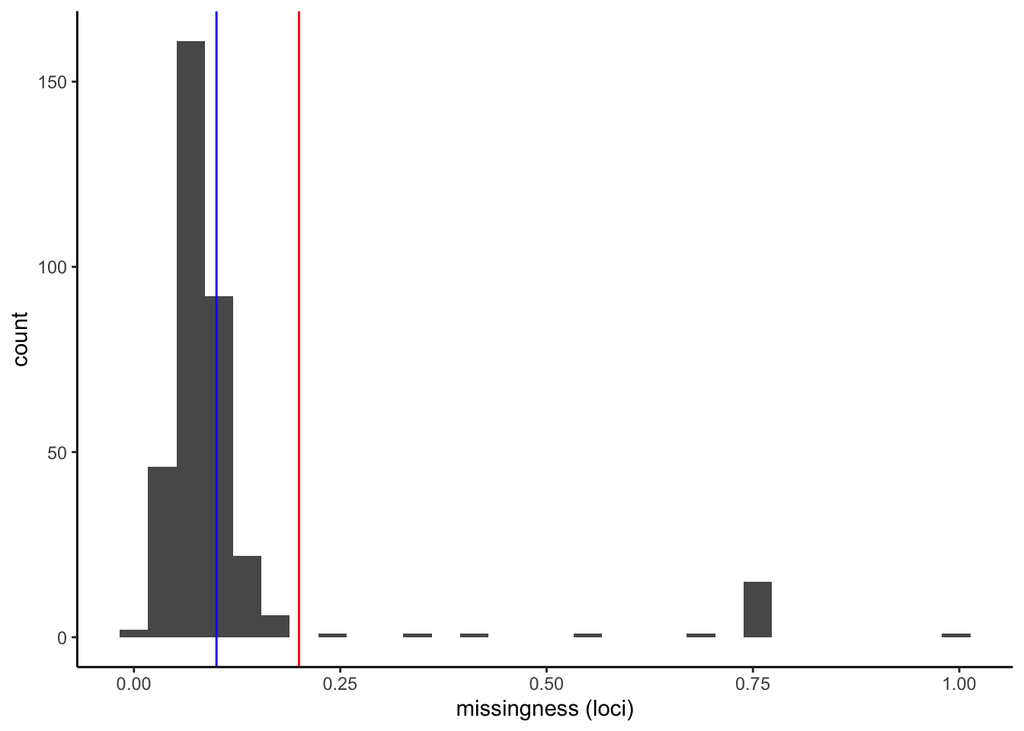

```r
missingness <- (colSums(genos_0.2[,c(7:(ncol(genos_0.2)-3))] == "00" | genos_0.2[,c(7:(ncol(genos_0.2)-3))] == "0"))/nrow(genos_0.2) #warning hardcoding: "[,8:398]" is hardcoded to work on the example script using the Omy panel with 390 markers, these values will need to be changed to reflect the genotype columns of the genos r object that YOU are running. This excludes columns with metadata and genotyping results such as "sample name" "ifi" "on-target reads" etc
missing <- as.data.frame(missingness)
missing$marker <- row.names(missing)
ggplot(missing) + geom_histogram(aes(x=missingness))+geom_vline(aes(xintercept= 0.2), color="red")+geom_vline(aes(xintercept= 0.1), color="blue")+theme_classic()+xlab("missingness (loci)")
```

Doesn’t look as great as normal, but that makes sense given that it’s chum samples. Now let’s make the datasets. The first step is to collect some information about genotying success from the .genos files. We’ll do this with an awk one liner.

The script below will pull the allele count ratios and read counts for all individuals in the pipeline

```bash
# now we'll cleanup marker info file  a little bit
#add headers: ind,marker,a1_count,a2_count,called_geno,a1_corr,a2_corr
#remove first rows sed -i '/Raw-Reads/d' ./marker_info.csv #first get rid of genos headers

# now clean up the "ind" field so that it matches your data
# depending on the file naming convention you used for your individuals this may need to change, for the example script we removed the leading "./" and the trailing lane information and file extension (e.g. "_L002_R1_001.genos"), but there's no way to standardize this step unless we standardize naming conventions all the way back to the library prep logs
```

Read in the marker info file and clean it up. Also clean up the genos sample names

```r
marker_info <- read_tsv("genotype_data/marker_info.txt")

#this part changes the values of A=2, G=898, -=52, etc for the allele count columns to the actual values
marker_info$a1_count <- as.numeric(substr(marker_info$a1_count, 3, nchar(marker_info$a1_count)))
marker_info$a2_count <- as.numeric(substr(marker_info$a2_count, 3, nchar(marker_info$a2_count)))
```

**0.3: Extremely Bad Loci and Individuals Excluded**

First remove the individuals and markers that clearly failed to genotype correctly (one step at a time)

```r
#print table of bad missingness individual
kable(genos_0.2 %>%
  filter(`%GT` < 70) %>%
    select(1:6), caption = "Individuals with high missingess (>30% missing data)")
```

Individuals with high missingess (>30% missing data)

| Sample | Raw Reads | On-Target Reads | %On-Target | %GT | IFI |
| --- | --- | --- | --- | --- | --- |
| OkeCC13MILC_7044_CTGATA_TCTTCT_S200_R1_001 | 1310031 | 1935 | 0.15 | 13.14 | 3.02 |
| OkeCC13MILC_9026_CTGATA_ACTGGC_S202_R1_001 | 974877 | 2718 | 0.28 | 22.00 | 4.14 |
| OkeCC19MILC_0028_run1 | 514808 | 1100 | 0.21 | 2.57 | 0.00 |
| OkeCC19MILC_0037_run1 | 470094 | 1404 | 0.30 | 3.14 | 4.14 |
| OkeCC19MILC_0053_run1 | 481994 | 2502 | 0.52 | 20.86 | 2.36 |
| OkeCC19MILC_0055_CAAATT_CATACT_S43_R1_001 | 319507 | 2555 | 0.80 | 22.00 | 0.71 |
| OkeCC19NETR_0002_CAAATT_CCGAGG_S75_R1_001 | 594679 | 4185 | 0.70 | 44.86 | 2.05 |
| OkeCC19NETR_0004_CAAATT_GCGACC_S77_R1_001 | 602327 | 2815 | 0.47 | 29.71 | 1.67 |
| OkeCC19NETR_0005_CAAATT_GTGCCT_S78_R1_001 | 1147208 | 4135 | 0.36 | 54.57 | 3.42 |
| OkeCC19NETR_0007_CTGATA_TGGGGA_S240_R1_001 | 899400 | 2677 | 0.30 | 25.43 | 2.71 |
| OkeCC19NETR_0008_CAAATT_ACCATG_S81_R1_001 | 857469 | 1481 | 0.17 | 10.57 | 2.59 |
| OkeCC19NETR_0011_CAAATT_CTTATG_S84_R1_001 | 1005359 | 5213 | 0.52 | 63.71 | 2.28 |
| OkeCC19NETR_0012_CAAATT_GCGCTG_S85_R1_001 | 763024 | 3712 | 0.49 | 43.71 | 1.32 |
| OkeCC19NETR_0015_CAAATT_TTTAAT_S88_R1_001 | 1213629 | 3470 | 0.29 | 37.14 | 2.85 |
| OkeCC19NETR_0018_CAAATT_CCTAAC_S91_R1_001 | 868846 | 41 | 0.00 | 0.00 | 0.00 |
| OkeCC19NETR_0021_CAAATT_GTTGGA_S94_R1_001 | 649616 | 3709 | 0.57 | 39.71 | 3.58 |
| OkeCC19NETR_0023_CAAACC_ACTCTT_S98_R1_001 | 1411424 | 2695 | 0.19 | 24.00 | 4.31 |
| OkeCC19NETR_0024_CAAACC_ATTCCG_S99_R1_001 | 1325992 | 1613 | 0.12 | 7.71 | 2.06 |
| OkeCC19TILR_0028_CAAACC_TACGGG_S127_R1_001 | 752343 | 3220 | 0.43 | 35.43 | 3.07 |
| OkeCC19TILR_0039_CAAACC_AATATC_S137_R1_001 | 905470 | 5820 | 0.64 | 69.14 | 3.65 |
| OkeCC19TILR_0130_CAAACC_CCGAGG_S171_R1_001 | 589893 | 2391 | 0.41 | 22.57 | 2.27 |
| OkeCC19YAQR_0072_CTGATA_CTTTGC_S284_R1_001 | 939804 | 5028 | 0.54 | 57.43 | 1.30 |

```r
# now remove them
genos_0.3 <- genos_0.2 %>%
  filter(`%GT` > 70)

#now recalculate locus level missingness after removing the worst individuals

missingness2 <- (colSums(genos_0.3[,c(7:(ncol(genos_0.3)-3))] == "00" | genos_0.3[,c(7:(ncol(genos_0.3)-3))] == "0"))/nrow(genos_0.3) #warning hardcoding: "c(8:(ncol(genos_0.3)-1))" is hardcoded to work on the example script. make sure this this only grabbing the columns that contian genotype data and not other columns (last column should be sample type, first 7 columns should have individual level summary data ) e.g. IFI
missing2 <- as.data.frame(missingness2)
missing2$marker <- row.names(missing2)

#then remove these markers
# collect bad markers
very_bad_markers <- missing2[missing2$missingness2>0.5, 2]
print(paste(length(very_bad_markers), "markers with > 50% missing data"))
```

```
## [1] "18 markers with > 50% missing data"
```

```r
#write the new dataset
genos_0.3 <- genos_0.3 %>%
  dplyr::select(-one_of(very_bad_markers))

#then recalculate IFI
# IFI is equal to the percentage of "background" reads to homozygote reads. Two types of reads contribute to background count: (1) Reads from the alternative allele when an individual has been called as homozygote at a locus, and (2) reads from the less frequent allele when the individual has been called as "in-betweener". We update the IFI score by including only markers in the filtered dataset


IFI <- marker_info %>%
  filter(marker %in% colnames(genos_0.3)) %>%
  group_by(ind) %>%
  summarize(back_count = sum(a1_count[called_geno == "A2HOM"], na.rm = TRUE)
            + sum(a2_count[called_geno == "A1HOM"], na.rm = TRUE)
            + sum(a1_count[is.na(called_geno) == TRUE & ((a1_count + a2_count)>=10) & (a2_count > a1_count)], na.rm = TRUE )
            + sum(a2_count[is.na(called_geno) == TRUE & ((a1_count + a2_count)>=10) & (a1_count > a2_count)], na.rm = TRUE ),

            hom_ct = sum(a1_count[called_geno == "A1HOM"], na.rm = TRUE)
            + sum(a2_count[called_geno == "A2HOM"], na.rm = TRUE)
            + sum(a2_count[is.na(called_geno) == TRUE & ((a1_count + a2_count)>=10) & (a2_count > a1_count)], na.rm = TRUE )
            + sum(a1_count[is.na(called_geno) == TRUE & ((a1_count + a2_count)>=10) & (a1_count > a2_count)], na.rm = TRUE ),

            ifi2 = (back_count/hom_ct)*100)

# the "marker_info" file we produced earlier used the filename of the genos file as the sample name (column name "ind"), but the sample names in our local R dataframes are very cleaned up (see line 504). Here I attempt to do the same using some regex in R using the standardized codes for sample naming at SFGL, but note that depending on how your fastq files are named, these exact matches may not work for you
# until we find a better solution I suggest two alternatives if this regex below breaks
# 1: if the number of high IFI samples is very low, just write the sample names out manually to a vector and use this to filter
# 2:

#IFI$sample <- str_extract(IFI$ind, "[:upper:][:lower:]{2}[AJCU][RC]\\d{2}\\w{4}_\\d{4}")
#IFI$adapter <- str_replace(IFI$ind, "(\\w+)[-_]([:upper:][:lower:]{2}[AJCU][RC]\\d{2}\\w{4}_\\d{4}).*", "\\1")


genos_0.3 <- genos_0.3 %>%
  left_join(select(IFI, ind,  ifi2), by = c("Sample" = "ind")) %>%
  mutate(IFI = ifi2) %>%
  select(-one_of("ifi2"))

# now filter on IFI
#print table of bad IFI samples
kable(genos_0.3 %>%
  filter(IFI >10) %>%
    select(2:7), caption = "Extreme High IFI (>10) samples (low confidence barcodes)")
```

Extreme High IFI (>10) samples (low confidence barcodes)

| Raw Reads | On-Target Reads | %On-Target | %GT | IFI | Oke_ACOT_100 |
| --- | --- | --- | --- | --- | --- |

```r
#update the  dataset
genos_0.3 <- genos_0.3 %>%
  filter(IFI < 10)
```

**Filtering log 0.2 -> 0.3:**  
22 inds removed with genotying success less than 70%  
18 loci removed with > 50% missingness  
0 indw with IFI >10

**0.4 Second Iteration Filter**

Next we do the same process, but at the final filtering levels:

- IFI_cutoff=5
- GTperc_cutoff=80 (inds greater than 10% missing data excluded)
- Missingness (loci) > 20%

```r
#print table of bad missingness individual
kable(genos_0.3 %>%
  filter(`%GT` < 80) %>%
    select(1:6), caption = "Individuals with high missingess (>10% missing data)")
```

Individuals with high missingess (>10% missing data)

| Sample | Raw Reads | On-Target Reads | %On-Target | %GT | IFI |
| --- | --- | --- | --- | --- | --- |
| OkeCC19MILC_0026_CTGATA_CGCGTG_S212_R1_001 | 705324 | 8465 | 1.20 | 76.86 | 3.979986 |
| OkeCC19NEHR_0007_CAAATT_GTAAGT_S54_R1_001 | 868543 | 8839 | 1.02 | 78.86 | 3.176844 |
| OkeCC19NETR_0003_CAAATT_CTGGTT_S76_R1_001 | 871255 | 7906 | 0.91 | 75.71 | 3.431668 |
| OkeCC19TILR_0020_CAAACC_TGACAA_S120_R1_001 | 1358995 | 32161 | 2.37 | 78.86 | 6.313282 |
| OkeCC19TILR_0050_CTGATA_ATCAAA_S266_R1_001 | 1167278 | 7539 | 0.65 | 73.43 | 3.721642 |
| OkeCC19TILR_0106_CTGATA_TCGCCA_S271_R1_001 | 706067 | 10563 | 1.50 | 79.71 | 4.943546 |
| OkeCC19TILR_0115_CAAACC_GTATCC_S158_R1_001 | 941674 | 7430 | 0.79 | 70.57 | 4.405286 |
| OkeCC19TILR_0127_CTGATA_TTTAAT_S280_R1_001 | 1719457 | 458001 | 26.64 | 76.00 | 5.182501 |

```r
# now remove them
genos_0.4 <- genos_0.3 %>%
  filter(`%GT` > 80)

#now recalculate locus level missingness after removing the worst individuals

missingness3 <- (colSums(genos_0.4[,c(8:(ncol(genos_0.4)-1))] == "00" | genos_0.4[,c(8:(ncol(genos_0.4)-1))] == "0"))/nrow(genos_0.4) #warning hardcoding: "c(8:(ncol(genos_0.3)-1))" is hardcoded to work on the example script. make sure this this only grabbing the columns that contian genotype data and not other columns (last column should be sample type, first 7 columns should have individual level summary data ) e.g. IFI
missing3 <- as.data.frame(missingness3)
missing3$marker <- row.names(missing3)

#then remove these markers
# collect bad markers
bad_markers <- missing3[missing3$missingness3>0.2, 2]
print(paste(length(bad_markers), "markers with > 20% missing data"))
```

```
## [1] "2 markers with > 20% missing data"
```

```r
#write the new dataset
genos_0.4 <- genos_0.4 %>%
  dplyr::select(-one_of(bad_markers))

#then recalculate IFI
# IFI is equal to the percentage of "background" reads to homozygote reads. Two types of reads contribute to background count: (1) Reads from the alternative allele when an individual has been called as homozygote at a locus, and (2) reads from the less frequent allele when the individual has been called as "in-betweener"

IFI <- marker_info %>%
  filter(marker %in% colnames(genos_0.4)) %>%
  group_by(ind) %>%
  summarize(back_count = sum(a1_count[called_geno == "A2HOM"], na.rm = TRUE)
            + sum(a2_count[called_geno == "A1HOM"], na.rm = TRUE)
            + sum(a1_count[is.na(called_geno) == TRUE & ((a1_count + a2_count)>=10) & (a2_count > a1_count)], na.rm = TRUE )
            + sum(a2_count[is.na(called_geno) == TRUE & ((a1_count + a2_count)>=10) & (a1_count > a2_count)], na.rm = TRUE ),

            hom_ct = sum(a1_count[called_geno == "A1HOM"], na.rm = TRUE)
            + sum(a2_count[called_geno == "A2HOM"], na.rm = TRUE)
            + sum(a2_count[is.na(called_geno) == TRUE & ((a1_count + a2_count)>=10) & (a2_count > a1_count)], na.rm = TRUE )
            + sum(a1_count[is.na(called_geno) == TRUE & ((a1_count + a2_count)>=10) & (a1_count > a2_count)], na.rm = TRUE ),

            ifi2 = (back_count/hom_ct)*100)

# the "marker_info" file we produced earlier used the filename of the genos file as the sample name (column name "ind"), but the sample names in our local R dataframes are very cleaned up (see line 504). Here I attempt to do the same using some regex in R using the standardized codes for sample naming at SFGL, but note that depending on how your fastq files are named, these exact matches may not work for you
# until we find a better solution I suggest two alternatives if this regex below breaks
# 1: if the number of high IFI samples is very low, just write the sample names out manually to a vector and use this to filter
# 2:

#IFI$sample <- str_extract(IFI$ind, "[:upper:][:lower:]{2}[AJCU][RC]\\d{2}\\w{4}_\\d{4}")
#IFI$adapter <- str_replace(IFI$ind, "(\\w+)[-_]([:upper:][:lower:]{2}[AJCU][RC]\\d{2}\\w{4}_\\d{4}).*", "\\1")


genos_0.4 <- genos_0.4 %>%
  left_join(select(IFI, ind, ifi2), by = c("Sample" = "ind")) %>%
  mutate(IFI = ifi2) %>%
  select(-one_of("ifi2"))

# now filter on IFI
#print table of bad IFI samples
kable(genos_0.4 %>%
  filter(IFI >5) %>%
    select(1:6), caption = "High IFI (>5) samples (low confidence barcodes)")
```

High IFI (>5) samples (low confidence barcodes)

| Sample | Raw Reads | On-Target Reads | %On-Target | %GT | IFI |
| --- | --- | --- | --- | --- | --- |
| OkeCC19TILR_0032_CAAACC_CAGGCA_S131_R1_001 | 822321 | 15804 | 1.92 | 80.57 | 5.230732 |

```r
#update the  dataset
genos_0.4 <- genos_0.4 %>%
  filter(IFI < 5)
```

## Paralogs

Now we manually examine allele counts for markers that may tag paralogues regions. Because our panels can contain hundreds of loci, we flag three types of markers for close scrutiny (below), but this is informal and you can also look at any marker you want using some of the scripts below.  
- Missingness (loci) > 10% - examine for allele correction issues  
- Markers where heterozygotes and “in-betweeners” do not follow 1:1 ratio of allele counts - Markers with high variance in ratio of allele counts at heteroyzgotes and “in-betweeners”

Let’s collect these markers, first markers with high missingness (10-20% missingness)

```r
# Local R

#get marker names of markers with 0.1 > missingness > 0.2
miss0.1 <- missing3[missing3$missingness3 > 0.1,]
miss_mod <- miss0.1[miss0.1$missingness3 < 0.2, 2]
```

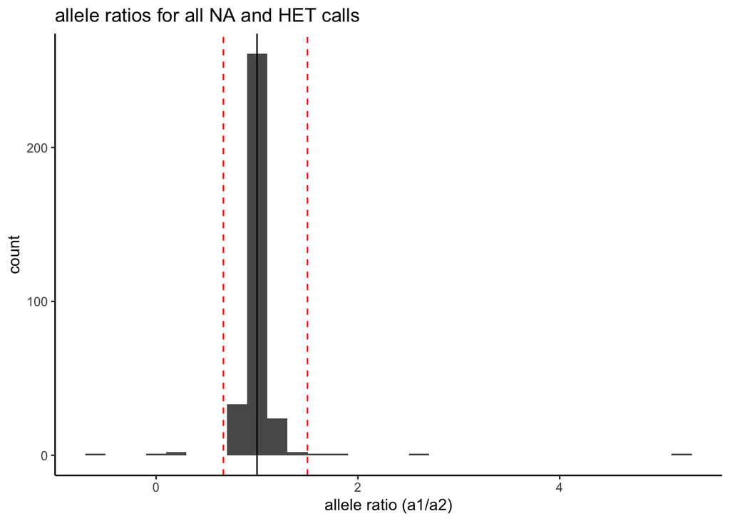

```r
library(lme4)
hets <- filter(marker_info, called_geno == "HET" | is.na(called_geno))

models <- hets %>%
  filter(marker %in% colnames(genos_0.4)) %>%
  filter(is.na(a1_count) == FALSE & is.na(a2_count) == FALSE) %>%
  group_by(marker) %>%
  group_map(~ lm(a1_count ~ a2_count, data= .))

# Apply coef to each model and return a list of allele count ratios
lms <- lapply(models, coef)
ggplot()+geom_histogram(aes(x = sapply(lms,`[`,2)))+theme_classic()+ggtitle("allele ratios for all NA and HET calls")+geom_vline(aes(xintercept = 1.5), color = "red", linetype = 2)+geom_vline(aes(xintercept = (2/3)), color = "red", linetype = 2)+xlab("allele ratio (a1/a2)")+geom_vline(aes(xintercept = 1), color = "black")
```

```r
#list of p-values
lms_anova <- lapply(models, summary)


# collect info about each bad model
paralog_possible <- which(abs(sapply(lms,`[`,2)) > 1.5) #bad because a positively skewed allele ratio
paralog_possible2 <- which(abs(sapply(lms,`[`,2)) < (2/3)) # bad because a negative skewed allele ratio

paralog_possible3 <- which(sapply(lms_anova, function(x) x$coefficients[,4][2])> 0.01) # bad because too much variance in allele ratio, even if mean ratio is 1

paralog_possible <- c(paralog_possible, paralog_possible2, paralog_possible3)
```

```r
# R Local

plots <- marker_info %>%
  filter(marker %in% colnames(genos_0.4)) %>%
  filter(is.na(a1_count) == FALSE & is.na(a2_count) == FALSE) %>%
  group_by(marker) %>%
  do(plots=ggplot(data=.)+geom_point(aes(a1_count, a2_count, color = called_geno))+theme_classic()+geom_abline(aes(slope=1, intercept=0))+geom_abline(aes(slope = 10, intercept=0), color = "green")+geom_abline(aes(slope = 0.1, intercept=0), color = "red")+geom_abline(aes(slope = 0.2, intercept=0), color = "blue")+geom_abline(aes(slope = 5, intercept=0), color = "blue")+coord_equal(ratio=1)+geom_abline(slope = -1, intercept = 10)+ggtitle(unique(.$marker)))

#plot all "bad markers"

#first add the missningness markers to the list to examine
mod_bad_plot_index <- which(plots$marker %in% miss_mod)
paralog_possible <- c(mod_bad_plot_index, paralog_possible)

# then loop through the plots by changing the index (here 33) until you have looked at all your questionable markers
plots$plots[[paralog_possible[10]]] #manually looped through these plots by changing the index for all 33 moderately bad markers, could make an lapply loop in the future, bad markers reported below
```

Only one marker showed evidence of tagging a paralog

```r
# Local R

to_filt <- c("Oke_RDDFW50712_39") # here list your bad marker names, if you have so many that this is unwieldy check out code snippet at bottom of this chunk
genos_0.5 <- genos_0.4 %>%
  dplyr::select(-one_of(to_filt))
```

### Monomorphic Markers and Duplicates

**1.0 Monomorphic Markers**

To generate the 1.0 dataset, we remove monomorphic markers

```r
genos_1.0 <- genos_0.5 %>%
  select_if(~ length(unique(.)) > 1)
```

# File Conversion and Stats

Final step of genotyping is to collect some stats about the genotype dataset and reformat the genotype file into common formats for import into other programs.

### Stats

Here are some summary stats and figures from your filtered dataset

```r
# LOCAL R
genos_2.0 <- genos_1.0

marker_info_filtered <- marker_info %>%
  filter(marker %in% colnames(genos_2.0)) %>%
  filter(ind %in% genos_2.0$Sample)

filtered_summary <- marker_info_filtered %>%
  mutate(total_count = a1_count+a2_count) %>%
  summarise(mean_depth = mean(total_count), median_depth= median(total_count), sd_depth = sd(total_count))

filtered_summary
```

| mean_depth | median_depth | sd_depth |
| --- | --- | --- |
| 933.6016 | 448 | 1150.213 |

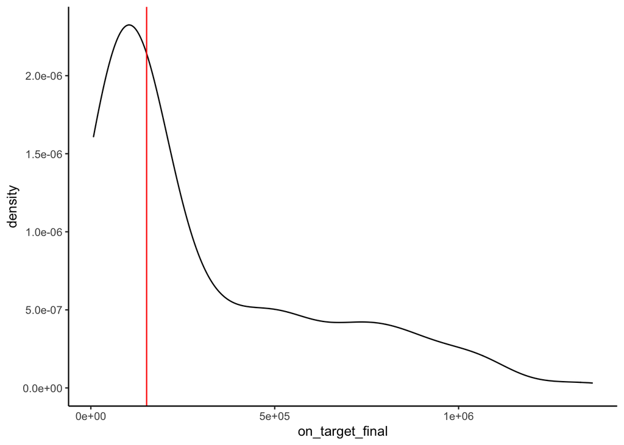

On Target Read Distribution

```r
filtered_on_target <- marker_info_filtered %>%
  mutate(total_count = a1_count+a2_count) %>%
  group_by(ind) %>%
  summarise(on_target_final = sum(total_count))

genos_2.0 %<>%
  left_join(filtered_on_target, by = c("Sample" = "ind"))

ggplot(genos_2.0)+geom_density(aes(x=on_target_final))+geom_vline(aes(xintercept=median(on_target_final)), color = "red") +theme_classic()
```

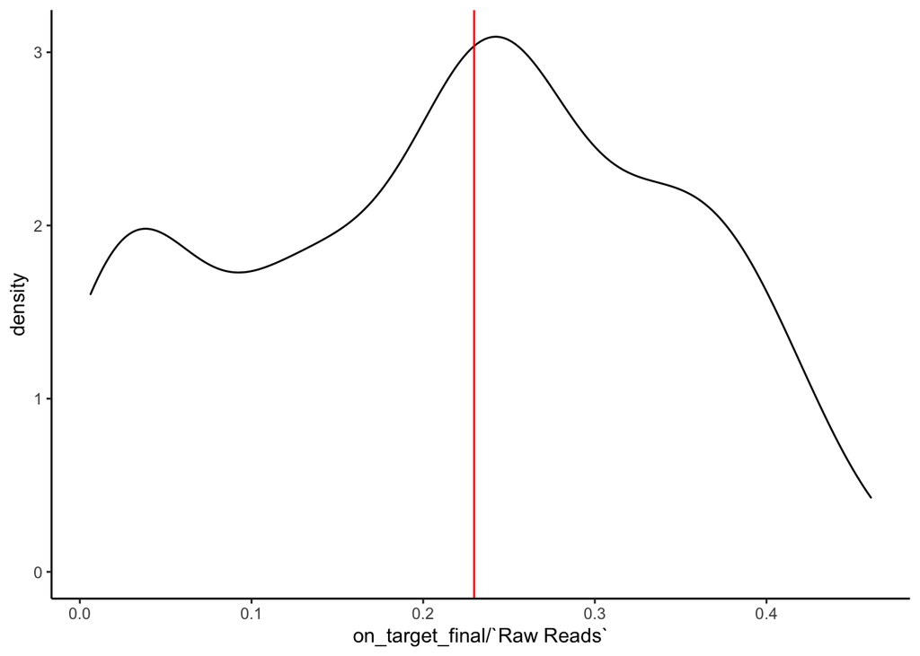

Proportion on Target

```r
#LOCAL R
ggplot(genos_2.0)+geom_density(aes(x=on_target_final/`Raw Reads`))+geom_vline(aes(xintercept=median(on_target_final/`Raw Reads`)), color = "red") +theme_classic()
```

**Stats of final filterd data set**

235 individuals X 325 Markers  
Depths: Mean-934, median-448, sd-1150

### Conversion

Let’s get some usable file formats

Here’s adegenet’s genind object

```r
#LOCAL R

# Convert to genind for import into adegenet

#first get a matrix to work on

#first change column to not include a dot
genos_2.1 <- genos_2.0
colnames(genos_2.1) <- gsub("\\.", "_", colnames(genos_2.1))
#convert to matrix with inds as row names
genos_2.1 <- as.matrix(genos_2.1[,c(7:331)]) #caution hardcoding, make sure you select just your marker columns
row.names(genos_2.1) <- genos_2.0$sample_simple
genind_1.0 <- df2genind(genos_2.1, sep ="", ploidy=2,NA.char = "0")

#add in the populations

genind_1.0@pop <- as.factor(genos_2.0$pop)
```

Finally, save your files as R objects for further analysis.

```r
# LOCAL R
#lets also tidy up the genos df

genos_2.0 %<>%
  relocate(sample_simple, pop) %>%
  select(-c(Sample, on_target_final))


genos_2.0 %<>%
  rename(sample = sample_simple)

# here we save a few objects with useful info
genind_2.0 <- genind_1.0
save(genos_2.0, file ="./genotype_data/genotypes_2.2.R")
save(genind_2.0, file= "./genotype_data/genind_2.0.R")
```